# Topic 1 Exercises

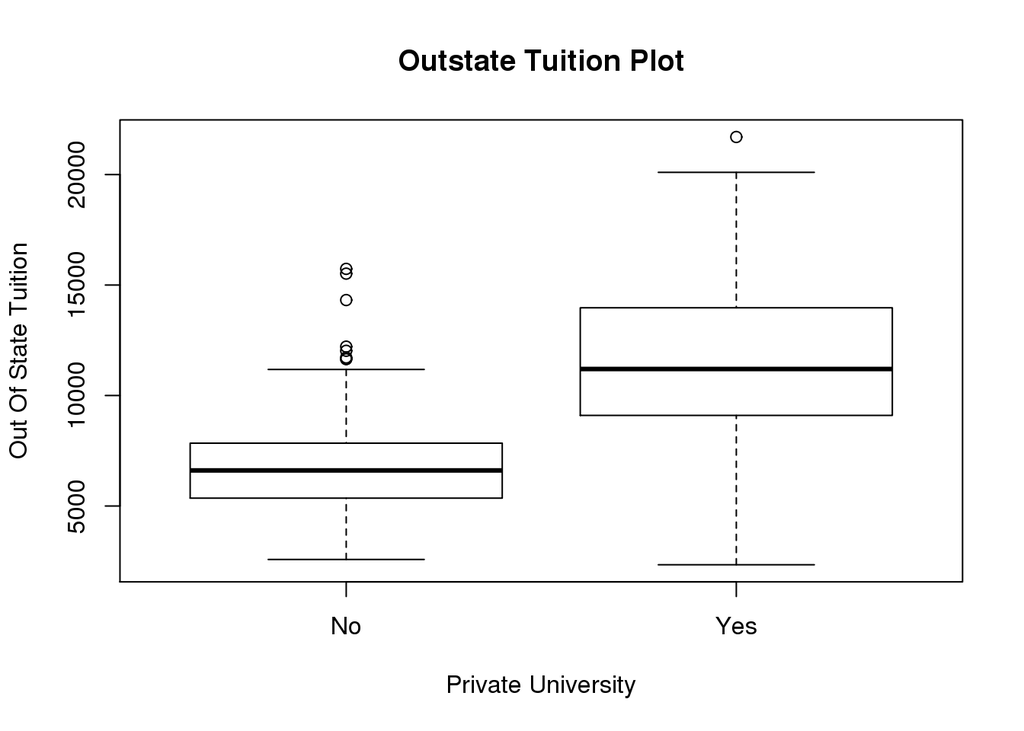

```r
plot(college$Private, college$Outstate, xlab = "Private University", ylab = "Out Of State Tuition", main = "Outstate Tuition Plot")
```

Part 4

```r
Elite = rep("No", nrow(college))
Elite[college$Top10perc > 50] = "Yes"
Elite = as.factor(Elite)
college = data.frame(college, Elite)
summary(college$Elite)
```

```
##  No Yes
## 699  78
```

There are 78 elite universities and 699 universities that are not elite.

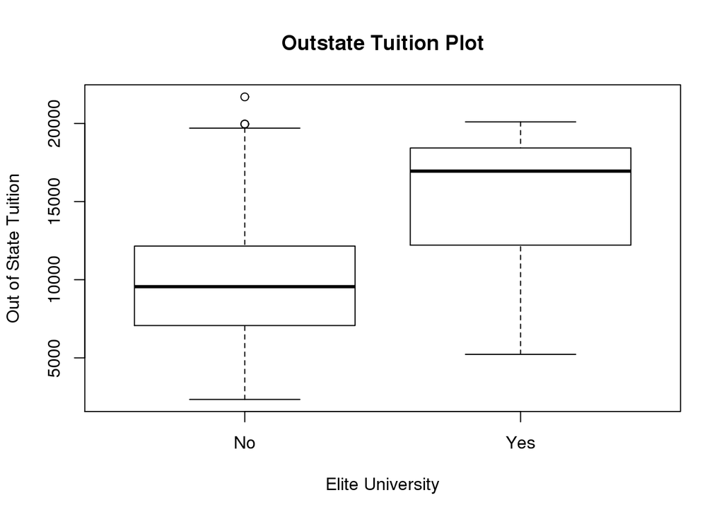

```r
plot(college$Elite, college$Outstate, xlab = "Elite University", ylab = "Out of State Tuition", main = "Outstate Tuition Plot")
```

Part 5

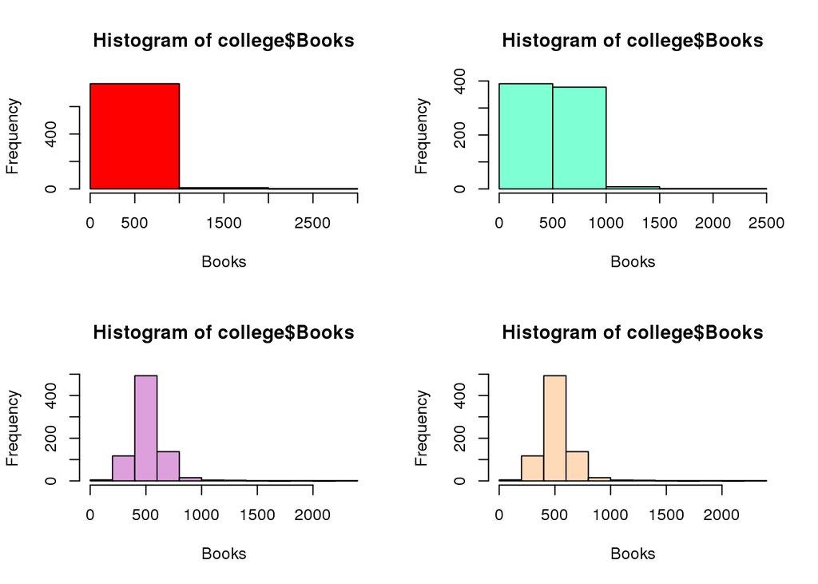

```r
par(mfrow=c(2,2))
hist(college$Books, col = "red", breaks = 3, xlab = "Books")
hist(college$Books, col = "aquamarine", breaks = 5, xlab = "Books")
hist(college$Books, col = "plum", breaks = 10, xlab = "Books")
hist(college$Books, col = "peachpuff", xlab = "Books")
```

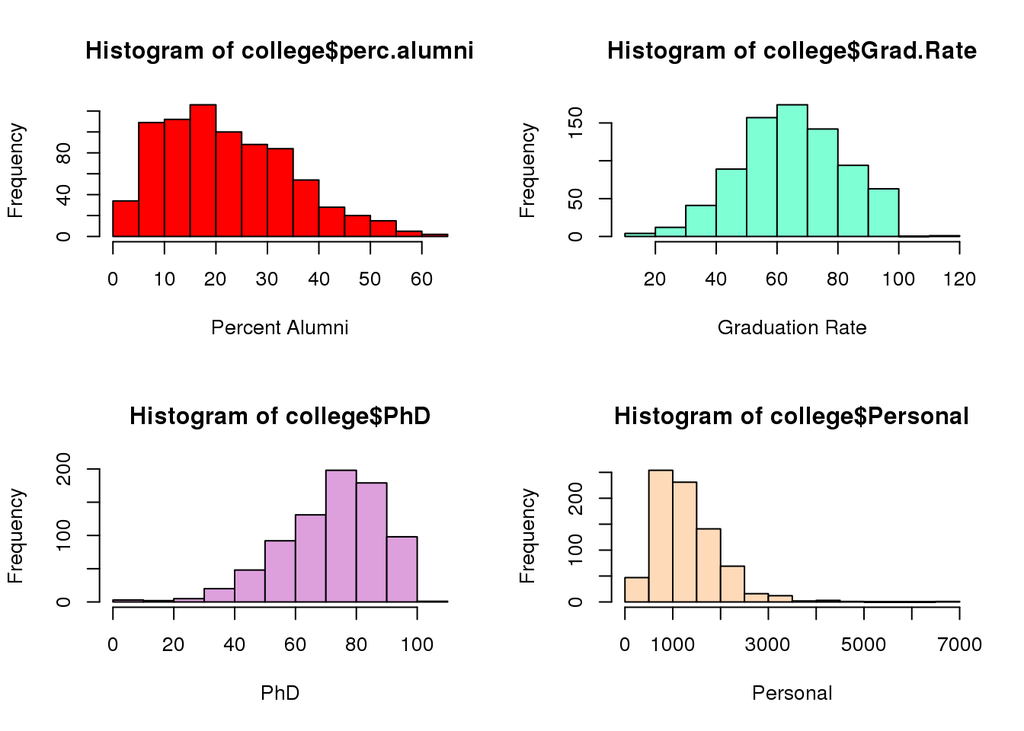

```r
par(mfrow=c(2,2))
hist(college$perc.alumni, col = "red", xlab = "Percent Alumni")
hist(college$Grad.Rate, col = "aquamarine", xlab = "Graduation Rate")
hist(college$PhD, col = "plum", xlab = "PhD")
hist(college$Personal, col = "peachpuff", xlab = "Personal")
```

Part 6 Continued data exploration:

```r
summary(college$Grad.Rate)
```

```
##    Min. 1st Qu.  Median    Mean 3rd Qu.    Max.
##   10.00   53.00   65.00   65.46   78.00  118.00
```

It seems odd that some universities have a 118% graduation rate. I want to find out how many universities this applies to and which universities they are.

```r
high_grad_rate <- college[college$Grad.Rate == 118,]
nrow(high_grad_rate)
```

```
## [1] 1
```

```r
rownames[as.numeric(rownames(high_grad_rate))]
```

```
## [1] Cazenovia College
## 777 Levels: Abilene Christian University ... York College of Pennsylvania
```

```r
summary(college$S.F.Ratio)
```

```
##    Min. 1st Qu.  Median    Mean 3rd Qu.    Max.
##    2.50   11.50   13.60   14.09   16.50   39.80
```

I want to know more about which universities have the a student/faculty ratio less than 5. Let’s see which universities meet this requirement.

```r
low_sf_ratio <- college[college$S.F.Ratio < 5,]
nrow(low_sf_ratio)
```

```
## [1] 7
```

```r
rownames[as.numeric(rownames(low_sf_ratio))]
```

```
## [1] Case Western Reserve University Dartmouth College
## [3] Johns Hopkins University        Saint Louis University
## [5] University of Charleston        Wake Forest University
## [7] Washington University
## 777 Levels: Abilene Christian University ... York College of Pennsylvania
```

### ISL 2.4.9

```r
data(Auto)
auto <- read.csv("Auto.csv", na.strings="?")
auto = na.omit(auto)

#download.file("http://www-bcf.usc.edu/~gareth/ISL/Auto.csv", destfile="Auto.csv")
#auto_file_name <- "/home/local/MAC/hsonsall/Math-253-Assignment/Auto.csv"
#auto <- read.csv(auto_file_name, na.strings="?")

# Omit rows containing missing observations
#auto = na.omit(Auto)
```

```r
summary(auto)
```

```
##       mpg          cylinders      displacement     horsepower
##  Min.   : 9.00   Min.   :3.000   Min.   : 68.0   Min.   : 46.0
##  1st Qu.:17.00   1st Qu.:4.000   1st Qu.:105.0   1st Qu.: 75.0
##  Median :22.75   Median :4.000   Median :151.0   Median : 93.5
##  Mean   :23.45   Mean   :5.472   Mean   :194.4   Mean   :104.5
##  3rd Qu.:29.00   3rd Qu.:8.000   3rd Qu.:275.8   3rd Qu.:126.0
##  Max.   :46.60   Max.   :8.000   Max.   :455.0   Max.   :230.0
##
##      weight      acceleration        year           origin
##  Min.   :1613   Min.   : 8.00   Min.   :70.00   Min.   :1.000
##  1st Qu.:2225   1st Qu.:13.78   1st Qu.:73.00   1st Qu.:1.000
##  Median :2804   Median :15.50   Median :76.00   Median :1.000
##  Mean   :2978   Mean   :15.54   Mean   :75.98   Mean   :1.577
##  3rd Qu.:3615   3rd Qu.:17.02   3rd Qu.:79.00   3rd Qu.:2.000
##  Max.   :5140   Max.   :24.80   Max.   :82.00   Max.   :3.000
##
##                  name
##  amc matador       :  5
##  ford pinto        :  5
##  toyota corolla    :  5
##  amc gremlin       :  4
##  amc hornet        :  4
##  chevrolet chevette:  4
##  (Other)           :365
```

The following predictors are quantitative: mpg, cylinders, displacement, horsepower, weight, acceleration, year and origin. The predictor name is categorical (qualitative).

2. Using the information from the summary command above, I was able to answer this question. The quantitative predictor mpg ranges from 9.0 to 46.6. The quantitative predictor cyclinders ranges from 3 to 8. The quantitative predictor displacement ranges from 68 to 455. The quantitative predictor horsepower ranges 46 to 230. The quantitative predictor weight ranges from 1613 to 5140. The quantitative predictor acceleration ranges from 8.0 to 24.8. The quantitative predictor year ranges from 70 to 82. The quantitative predictor origin ranges from 1 to 3.

```r
sapply(auto[, -c(9)], mean)
```

```
##          mpg    cylinders displacement   horsepower       weight
##    23.445918     5.471939   194.411990   104.469388  2977.584184
## acceleration         year       origin
##    15.541327    75.979592     1.576531
```

```r
sapply(auto[, -c(9)], sd)
```

```
##          mpg    cylinders displacement   horsepower       weight
##    7.8050075    1.7057832  104.6440039   38.4911599  849.4025600
## acceleration         year       origin
##    2.7588641    3.6837365    0.8055182
```

```r
auto_subset <- auto[-c(10:85),-c(9)]
sapply(auto_subset, range)
```

```
##       mpg cylinders displacement horsepower weight acceleration year
## [1,] 11.0         3           68         46   1649          8.5   70
## [2,] 46.6         8          455        230   4997         24.8   82
##      origin
## [1,]      1
## [2,]      3
```

```r
sapply(auto_subset, mean)
```

```
##          mpg    cylinders displacement   horsepower       weight
##    24.404430     5.373418   187.240506   100.721519  2935.971519
## acceleration         year       origin
##    15.726899    77.145570     1.601266
```

```r
sapply(auto_subset, sd)
```

```
##          mpg    cylinders displacement   horsepower       weight
##     7.867283     1.654179    99.678367    35.708853   811.300208
## acceleration         year       origin
##     2.693721     3.106217     0.819910
```

5. I created a scatterplot matrix, a scatterplot for every pair of variables for the Auto data set

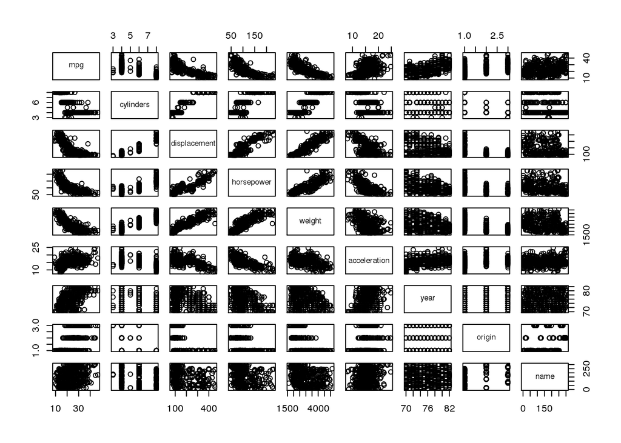

```r
pairs(auto[,])
```

These scatterplots are able to highlight many relationships among predictors. It is evident that newer cars (as years increase) tend to have better mpg. It also appears that Japanese cars (3) have better mpg than European cars (2) and American cars (1). Cars with 4 cylinders tend to have higher mpg than cars with 3,5,6 or 8 cylinders. It seems that as displacement, horsepower and weight increase, mpg decreases. It is hard to tell exactly what the relationship between mpg and name is, although I doubt that there is anything worthwhile.

We can also look at the predictor origin. The plots indicate that American cars have greater displacement, horsepower and weight. European cars have the fastest acceleration. It seems that many cars have American names.

6. Using the scatterplots from the previous question, I can confidently say that cylinders, year and origin can be used as predictors for mpg. The relationship between these variables and mpg is rather distinct. Displacement, horsepower and weight all look to have a similar relationship with mpg. If need be, we could use one of these three as a predictor, but there is no need to incorporate all of them.

## Theory Assignment

### ISL 2.4.2

Explain whether each scenario is a classification or regression problem, and indicate whether we are most interested in inference or prediction. Finally, provide n and p.

1. We collect a set of data on the top 500 firms in the US. For each firm we record profit, number of employees, industry and the CEO salary. We are interested in understanding which factors affect CEO salary.

This scenario is a regression problem as the response variable, CEO salary is quantitative. We are most interested in inference, that is we want to further understand the relationship between the response (CEO salary) and the predictors (profit, number of employees, industry). For this problem, $n$ = 500 and $p$ = 3.

2. We are considering launching a new product and wish to know whether it will be a success or a failure. We collect data on 20 similar products that were previously launched. For each product we have recorded whether it was a success or failure, price charged for the product, marketing budget, competition price, and ten other variables.

This scenario is a classification problem as the response variable, success or failure, is qualitative. We are most interested in prediction, that is we want to predict in the future whether products will be successful or fail. For this problem, $n$ = 20 and $p$ = 13.

3. We are interesting in predicting the % change in the US dollar in relation to the weekly changes in the world stock markets. Hence we collect weekly data for all of 2012. For each week we record the % change in the dollar, the % change in the US market, the % change in the British market, and the % change in the German market.

This scenario is a regression problem as the response variable, % change is US dollar is quantitative. We are most interested in prediction, that is we want to predict in the future the % change in the US dollar. For this problem, $n$ = 52 and $p$ = 3.

### ISL 2.4.7

1. Compute the Euclidean distance between each observation and the test point, X1 = X2 = X3 = 0.

```r
#Observation 1
sqrt((0-0)^2 + (0-3)^2 + (0-0)^2)
```

```
## [1] 3
```

```r
#Observation 2
sqrt((0-2)^2 + (0-0)^2 + (0-0)^2)
```

```
## [1] 2
```

```r
#Observation 3
sqrt((0-0)^2 + (0-1)^2 + (0-3)^2)
```

```
## [1] 3.162278
```

```r
#Observation 4
sqrt((0-0)^2 + (0-1)^2 + (0-2)^2)
```

```
## [1] 2.236068
```

```r
#Observation 5
sqrt((0--1)^2 + (0-0)^2 + (0-1)^2)
```

```
## [1] 1.414214
```

```r
#Observation 6
sqrt((0-1)^2 + (0-1)^2 + (0-1)^2)
```

```
## [1] 1.732051
```

2. What is our prediction with K = 1? Why?

If K = 1, then we use observation 5 since it is the closest observation to X0. Observation 5 is green and the resulting probability for our estimation is 1/1 for green. Our prediction is green.

3. What is our prediction with K = 3? Why?

If K = 3, then we use observations 5, 6 and 2 since these are the 3 closest observations to X0. Observations 2 and 6 are red, whereas observation 5 is green. In this case, our prediction is red since 2 out of the 3 observations are red and only 1 out of the 3 observations is green.

4. If the Bayes decision boundary in this problem is highly nonlinear, then would we expect the best value for K to be large or small? Why?

If the decision boundary is highly nonlinear, we would expect the best value for K to be small. As K grows, the method becomes less flexible and creates a decision boundary that is almost linear.